# Basic Plots and Data Gazing

Rachael ‘Rocky’ Aikens, Voight Lab

July 6, 2017

This document contains notes and visualizations of mutation rates for patterns of mutation on the 3mer, 5mer, and 7mer level which are interesting either because of their significance in heterogeneity test or the way that they cluster together in heatmaps.

# Methodology

I use a handful of different plotting methods to gain different perpectives on the data. These are:

- **CI.plot** Given count dataframes for four populations and a polymorphism of interest $m$, plot the inferred mutation rates of $m$ in each population with approximate confidence intervals.
- **chrom.box** Given count dataframes for four populations, a polymorphism of interest $m$, and a dataframe of genome wide context counts, plot the inferred mutation rates of $m$ in each on each chromosome as a boxplot, labeling outliers.
- **subrate.scplot** Given count dataframes for two populations and a 3mer polymorphism type, find the rates of all expansions of that threemer in those populations and plot them against each other.
- **subrate.lplot** Given count dataframes for each non-admixed continental group and a 3mer polymorphism type, find the rates of all 5mer expansions of that threemer in those populations and plot them as as lines across the populations.

# Mutation rate differences at the 3mer level

14 most highly significant 3mers

| Context | X1mer | AFR.Count | EUR.Count | EAS.Count | SAS.Count | p |
| --- | --- | --- | --- | --- | --- | --- |
| TCC->T | C->T | 129676 | 37083 | 36252 | 43951 | 0.000000e+00 |
| ACC->T | C->T | 135088 | 29880 | 35002 | 40890 | 3.000000e-308 |
| TCT->T | C->T | 144254 | 30975 | 39522 | 43187 | 2.868119e-196 |
| GAT->T | A->T | 47152 | 9181 | 15883 | 15054 | 5.361344e-111 |
| ACC->A | C->A | 76646 | 14684 | 24481 | 23819 | 1.248600e-98 |
| CCC->T | C->T | 133143 | 26025 | 35129 | 38511 | 2.154370e-69 |
| ACA->T | C->T | 227803 | 39876 | 58806 | 62287 | 2.904922e-60 |
| TCA->T | C->T | 134514 | 26126 | 36472 | 38964 | 9.743309e-52 |
| ACT->T | C->T | 157475 | 29610 | 41237 | 44484 | 3.142140e-51 |
| TCG->T | C->T | 202752 | 37854 | 58472 | 60351 | 1.556530e-49 |
| ACG->T | C->T | 331572 | 61298 | 95484 | 97290 | 2.090019e-48 |
| GCG->T | C->T | 230676 | 42837 | 66845 | 67786 | 3.756211e-45 |
| GCT->T | C->T | 136895 | 25668 | 40513 | 40199 | 1.791085e-40 |
| GAC->T | A->T | 21353 | 4012 | 7135 | 6569 | 6.496890e-40 |

## Signal 1: European C->T Elevation

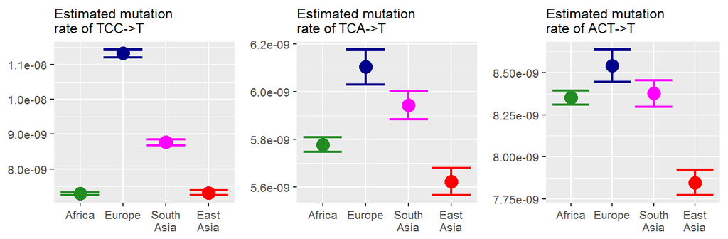

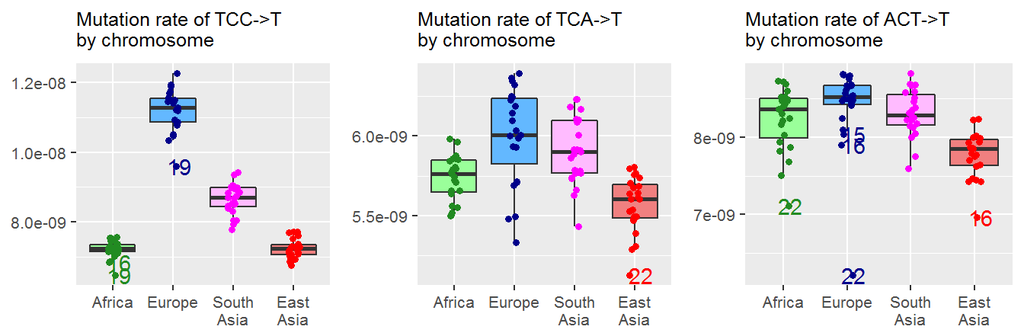

Note that although these patterns appear similar in EUR, EAS, and SAS, there are noteable differences between the relative rates in Africa. This seems to be common among the C->T signal polymorphisms. Consider for example CCC->T:

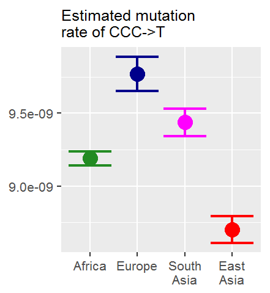

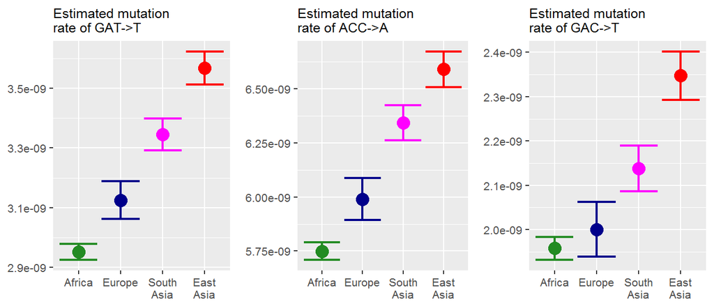

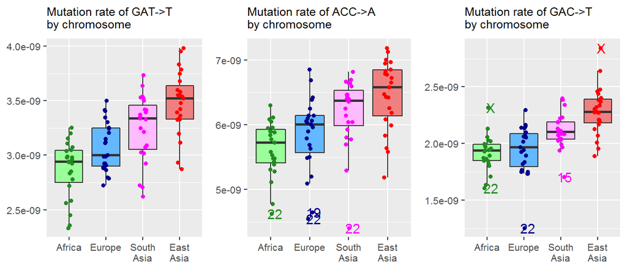

## Signal 3: CpG transitions

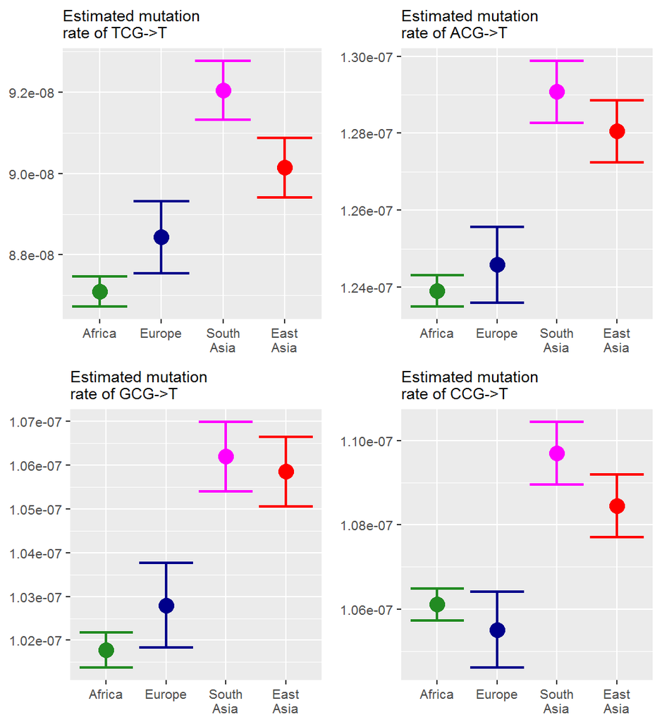

It is worth nothing that the CpG mutations cluster together in heatmaps, even after normalization.

## Signal 4: Heterogeneity within East Asia

When we construct a heatmap of all 3mers, we find two clusters which appear enriched in Japan and other groups in East Asia. These clusters are comprised of the *AC->C polymorphisms, as well as TAT->T. When the mutational types are clustered using only the data from East Asia, excluding other continental groups, we find that these two clusters merge, and the additional polymorphism CAC->C is added. This group is in correspondence with results from Harris and Pritchard, who find that *AC->C, TAT->T, and CAC->C mutation types separate East Asians in a principal component analysis.

These mutation types have the global profiles shown below:

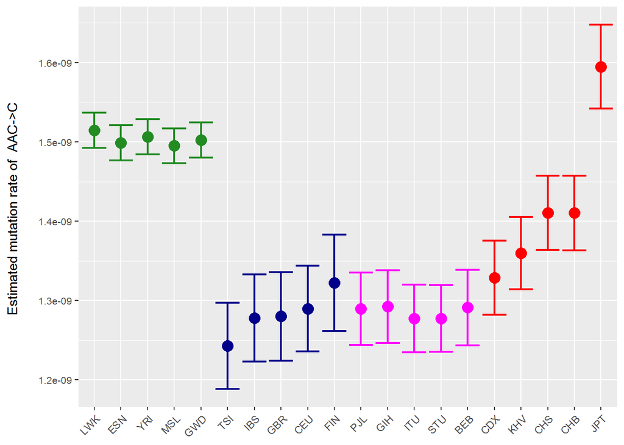

## Additional Signals

Two remaining polymorphism types have not yet been mentioned. The first highly significant signal which has not been is ACA->T, which appears elevated in Africa.

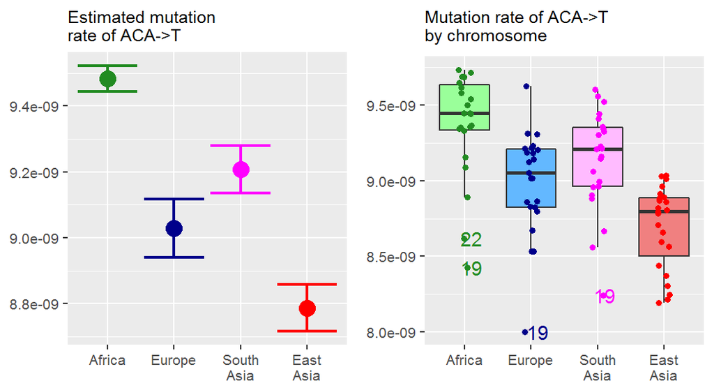

The second is GCC->T,which is elevated in East Asia in addition to Europe and South Asia.

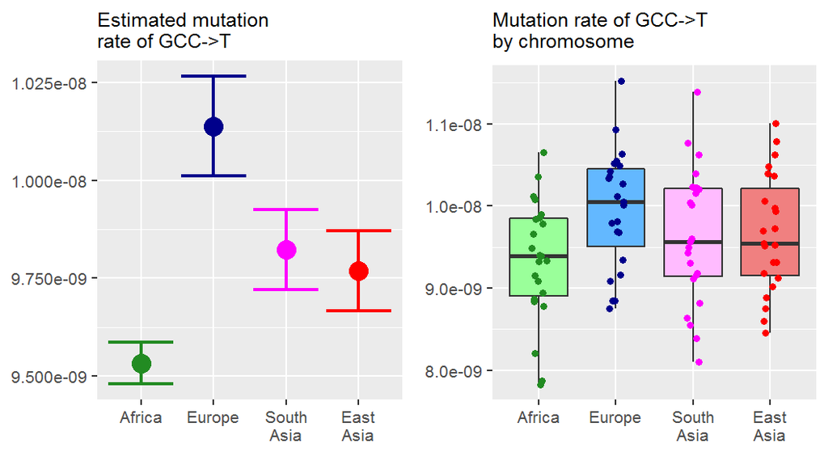

Finally, an additional pattern of interest is the shared profiles of certain CpG transversions, which appear to be enriched in Africa, and which cluster together in heatmaps. However, none of these polymorphism types are significant based on homogeneity tests (predictably, since CpG transversions are rare), and Harris and Pritchard have noted that the proportions of CpG transversions in 1,000 genomes and the Simmons Diversity Genome Project dataset tend not to agree, suggesting that this pattern may be driven by some sequencing artifact.

# Heterogeneity of 3mer signals within higher order sequence context models

Now that we have identified several groups of 3mer polymorphisms which appear to vary across populations, we would like to know whether local sequence context (up to 3 bases from the substitution) plays a role in driving the variation we observe. To do this, we can bin the polymorphisms from any given 3mer (say, TCC->T) into 256 different 7mer expansions (e.g. ACTCCCT->A), and observe how their rates differ between populations.

We’ll begin with a simple null example. The CpG transition CCG->T is relatively the same within East Asia. In this case, we expect to see some variation in rate between CCG->T expanisions due to 7mer effects that are uniform across all populations. However, we expect the rates of any given 7mer to be equal between East Asian subpopulations. This is what we see below, in Chinese Dai versus Japanese from Tokyo:

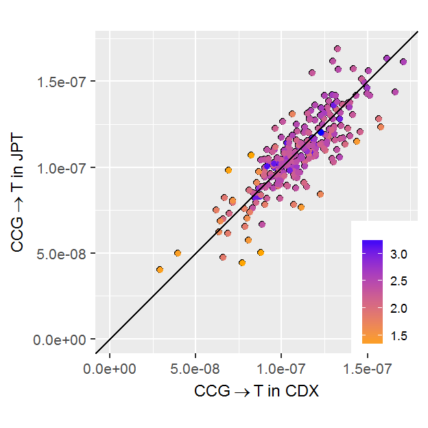

Here, each point represents a polymorphism, and the points are colored by the base 10 log of sample size (number of polymorphisms observed). We see some noise here, mostly among the yellow-colored (more uncertain) polymorphisms. However, most points lie along the y = x line.

## Signal 1: European C->T elevation

For each signal we’ve highlighted at the 3mer level, we’d like to know whether this is a true 3mer effect or whether this is driven by broader sequence context.

Let’s consider the top 3mer polymorphisms for the European C->T elevation, shown on the next page. Here, we can see that, for each polymorphism type, the distribution of all 7mers lies slightly above the y = x line. This indicates that signal 1 is determined by local sequence context effects at 1 or fewer base pairs from the substitution locus.

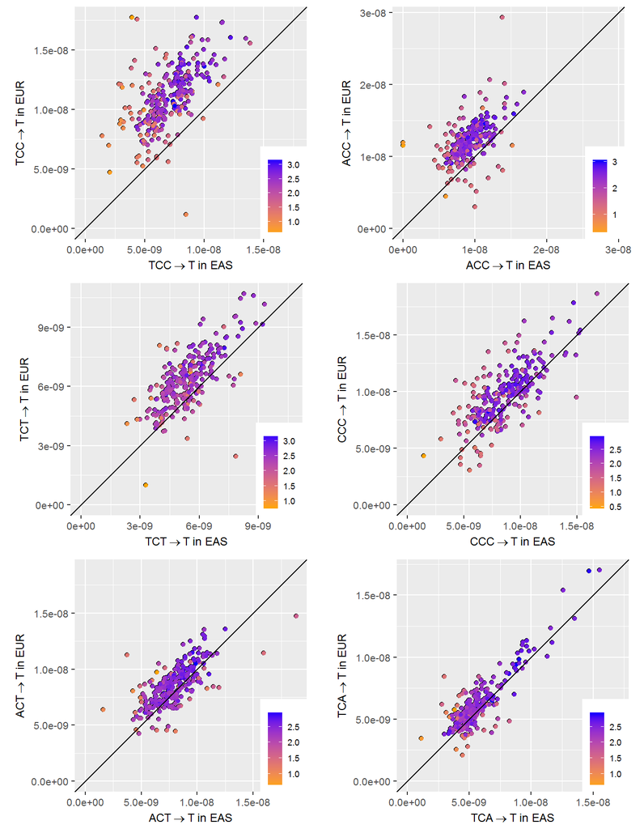

## Signal 2: Enrichment of certain polymorphisms in East Asia

We come to a similar conclusion for Signal 2:

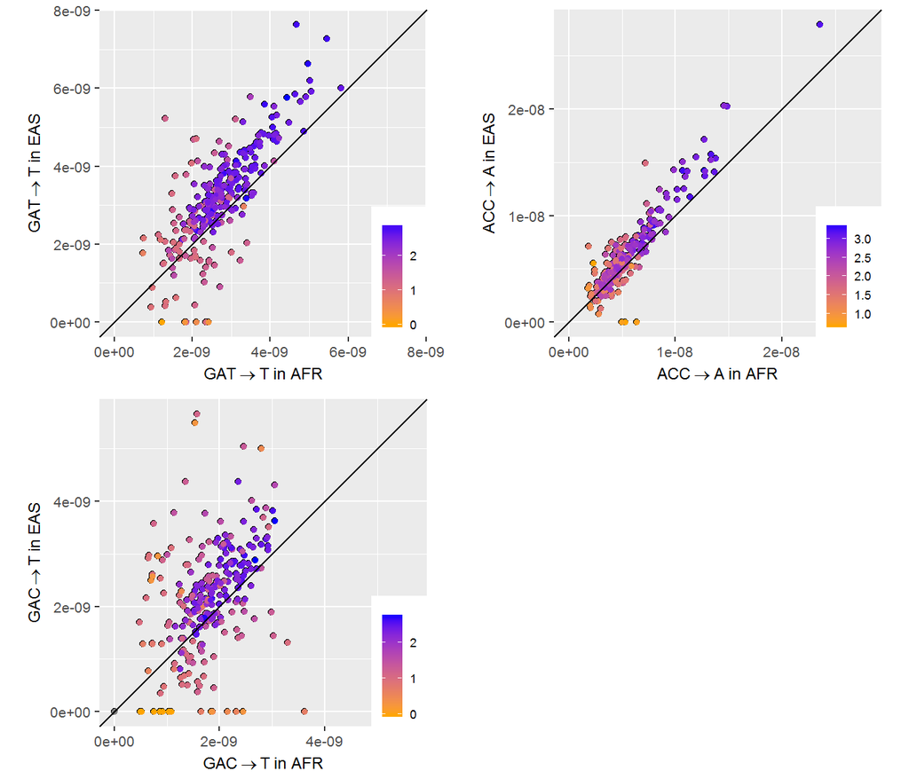

## Signal 3: CpG polymorphisms

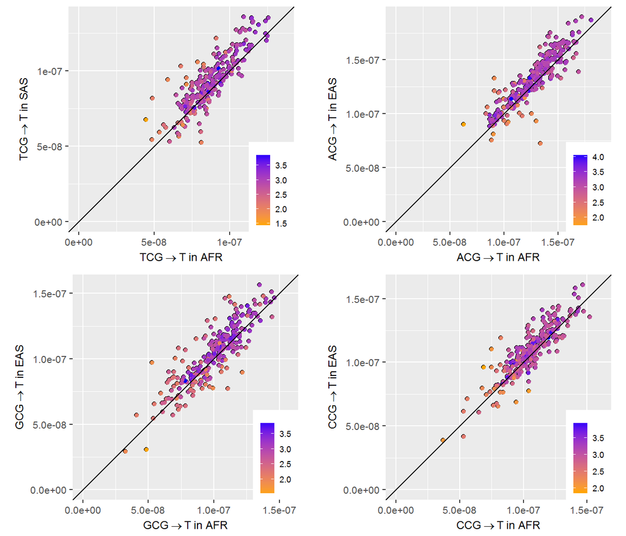

## Signal 4: Heterogeneity within East Asia

Now we shift to discussing the fourth signal: *AC->C and TAT->T, which appear to be elevated in East Asia, most notably in certain individuals from Japan and China. In order to understand how this mutation type varies within East Asia, I will plot the rates of these polymorphisms in Japan versus Chinese Dai in Xishuangbana. These can be seen on the following page. In contrast to the previous plots, most points lie along the line y = x, with a few outliers. This indicates that some cues among the 7mer sequence context may be important.

Intrigued by these findings, we set out to begin to identify putative 7mer types responsible for this signature. To this end, we considered each of the 1280 possible 7mer expansions *AC->C and TAT->T 3-mer substitutions, testing for heterogeneity between Japanese from Tokyo (JPT, higher signature 4 polymorphism proportion) and Chinese Dai from Xishuangbana (CDX, lower signature 4 polymorphism proportion).

| Context | p | fdr |
| --- | --- | --- |
| TTTATTT->T | 0.0000000 | 0.0000000 |
| AAGACAG->C | 0.0003943 | 0.0277929 |
| AATACAG->C | 0.0003943 | 0.0277929 |
| ACAACAG->C | 0.0003970 | 0.0277929 |
| ACCACCA->C | 0.0002571 | 0.0256823 |
| AGTACAG->C | 0.0000000 | 0.0000001 |
| ATAACAG->C | 0.0000093 | 0.0011780 |
| ATCACAG->C | 0.0004174 | 0.0277929 |
| ATGACAG->C | 0.0000103 | 0.0011780 |
| CAAACCC->C | 0.0000000 | 0.0000000 |
| CCCACAG->C | 0.0000097 | 0.0011780 |
| GTGACAG->C | 0.0004664 | 0.0286643 |
| TCAACAG->C | 0.0000045 | 0.0008978 |
| TTTATTA->T | 0.0007946 | 0.0453474 |

Among these polymorphisms, the motif ACAG->C appears to be very common.

```r
binom.test(4,9,0.05)$p.value
```

```
## [1] 0.0006425747
```

| Context | Autosomes | X | Autosomal_sites | X_sites | alpha | p.0 | p.MLE | p |
| --- | --- | --- | --- | --- | --- | --- | --- | --- |
| TTTATTT->T | 743 | 65 | 1444601 | 119969 | 0.770283 | 0.000396 | 0.000542 | 0.009215 |
| AAGACAG->C | 50 | 4 | 298423 | 24142 | 0.770283 | 0.000129 | 0.000166 | 0.378682 |
| AATACAG->C | 44 | 1 | 258885 | 21463 | 0.770283 | 0.000131 | 0.000047 | 0.939798 |
| ACAACAG->C | 34 | 3 | 202230 | 17800 | 0.770283 | 0.000130 | 0.000169 | 0.405338 |
| ACCACCA->C | 48 | 3 | 266068 | 19888 | 0.770283 | 0.000139 | 0.000151 | 0.521860 |
| AGTACAG->C | 51 | 4 | 143524 | 10787 | 0.770283 | 0.000274 | 0.000371 | 0.342137 |
| ATAACAG->C | 50 | 4 | 185557 | 15802 | 0.770283 | 0.000208 | 0.000253 | 0.415215 |
| ATCACAG->C | 57 | 4 | 216095 | 15185 | 0.770283 | 0.000203 | 0.000263 | 0.371870 |
| ATGACAG->C | 39 | 4 | 196359 | 15670 | 0.770283 | 0.000153 | 0.000255 | 0.220716 |
| CAAACCC->C | 101 | 27 | 136995 | 10993 | 0.770283 | 0.000568 | 0.002456 | 0.000000 |
| CCCACAG->C | 80 | 25 | 206875 | 15550 | 0.770283 | 0.000298 | 0.001608 | 0.000000 |
| GTGACAG->C | 24 | 1 | 228147 | 15040 | 0.770283 | 0.000081 | 0.000066 | 0.704399 |
| TCAACAG->C | 35 | 7 | 165015 | 13875 | 0.770283 | 0.000163 | 0.000505 | 0.008691 |
| TTTATTA->T | 209 | 15 | 577465 | 47331 | 0.770283 | 0.000279 | 0.000317 | 0.344927 |

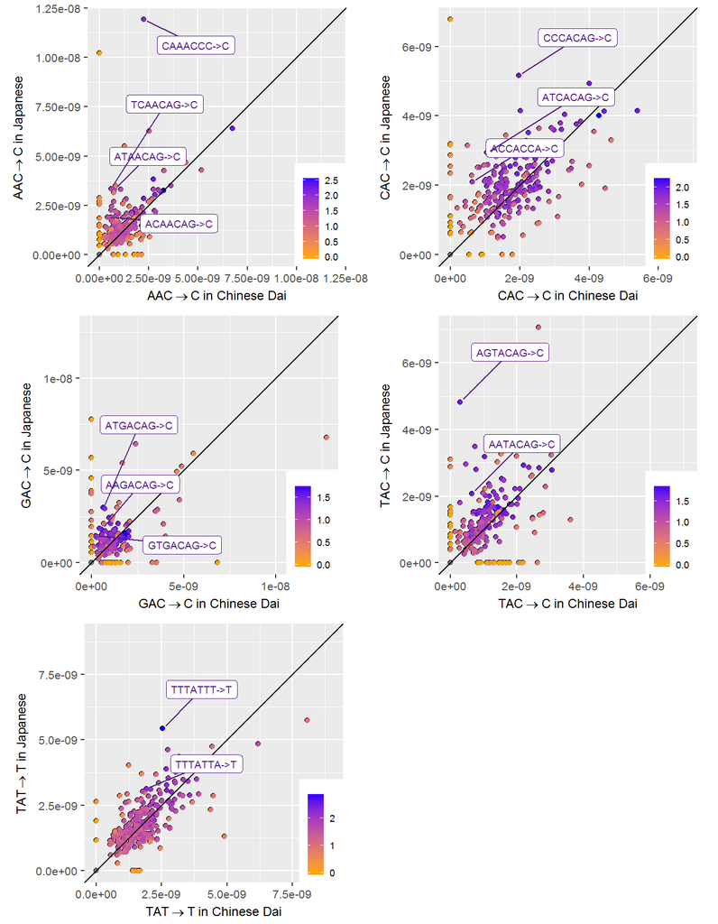

## Additional 3mer signals

Here is ACA->T

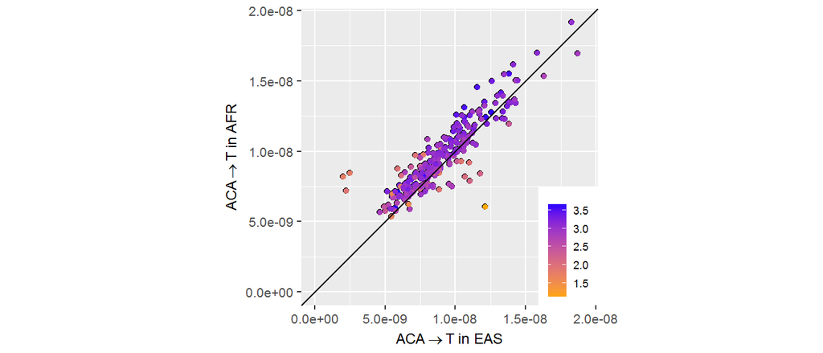

The last signal is GCC->T:

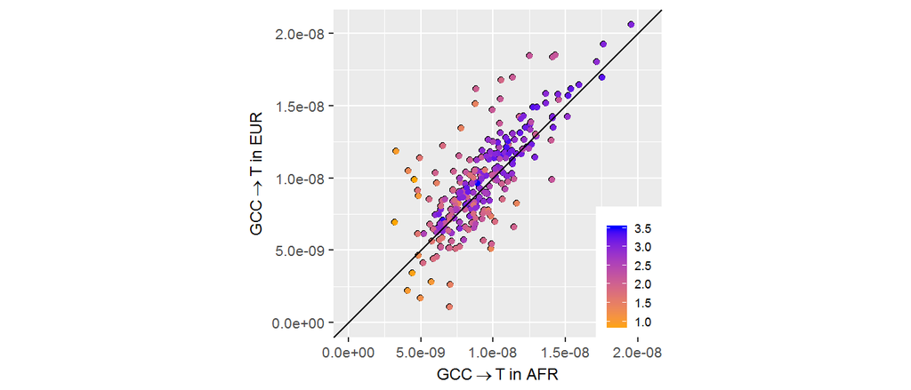

This one appears also to be a 3mer signal, but the whole story may be more complicated, since we are seeing some abnormal results at the 5mer level (see notebook).

# Novel mutation rate differences at the 7mer level

After removing known 3mer signals (TCC->T, ACC->T, TCT->T, ATC->C, ACC->C, and GAT->T), we have the following top significant results for 7mers:

10 most highly significant 7mers, after removing top 3mer signals

| Context | X3mer | AFR.Count | EUR.Count | EAS.Count | SAS.Count | p |
| --- | --- | --- | --- | --- | --- | --- |
| CAAACCC->C | AAC->C | 127 | 22 | 128 | 12 | 2.984752e-39 |
| TTTATTT->T | TAT->T | 2796 | 431 | 808 | 478 | 2.166804e-25 |
| TTTAAAA->T | TAA->T | 12011 | 1961 | 2939 | 2846 | 1.199912e-21 |
| ATTAAAA->T | TAA->T | 3773 | 496 | 857 | 808 | 1.968521e-21 |
| AAACAAA->A | ACA->A | 3108 | 446 | 766 | 578 | 2.110224e-21 |
| AGTACAG->C | TAC->C | 51 | 14 | 55 | 9 | 2.375565e-15 |
| ACTAAAA->G | TAA->G | 2187 | 513 | 833 | 705 | 2.887438e-15 |
| CTGCATA->G | GCA->G | 72 | 19 | 63 | 12 | 7.903406e-14 |
| TATATAT->G | TAT->G | 7093 | 1181 | 1710 | 1724 | 3.338030e-11 |
| AGGCTTT->T | GCT->T | 1174 | 177 | 442 | 339 | 4.507439e-09 |

## Additional polymorphisms heterogeneous in East Asia

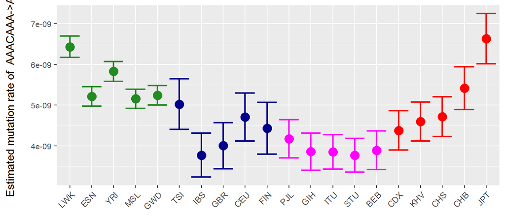

## TAA->T

The remaining polymorphisms are all within A->T rich contexts. Here we examine the first, a pair of polymorphisms with the 3mer subcontext TAA->T.

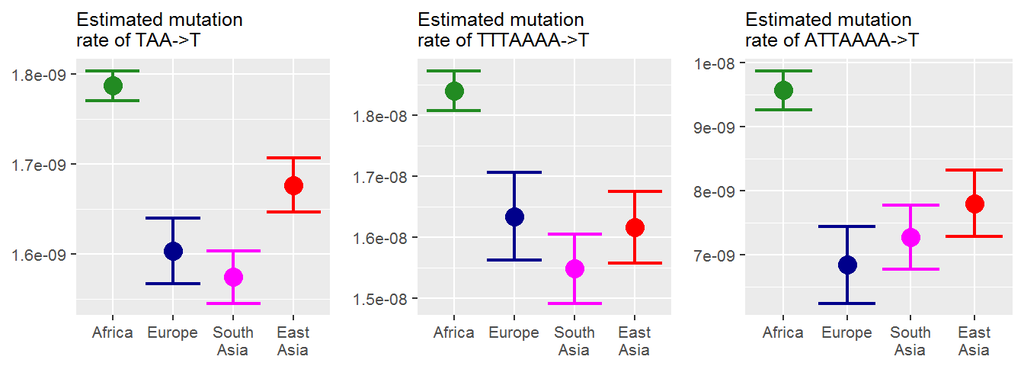

For the most part, the profiles of TTTAAAA->T and ATTAAAA->T match that of the broader 3mer subcontext. However, upon closer examination we find that TTTAAAA->T may be outlier contexts. For most other TAA->T exansions, in fact, the rates in Africa are in agreement with the rates in Europe. Only these two highly variable contexts appear to be driving the signal on the 3mer level.

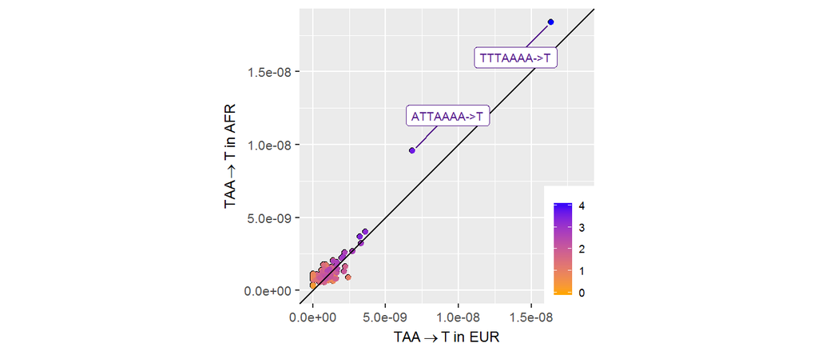

## TAA->G

Surprisingly, TAA->G has an altogether different pattern than TAA->T. Again, we see that the 3mer subcontext is more or less in agreement with the profile of this 7mer expansion.

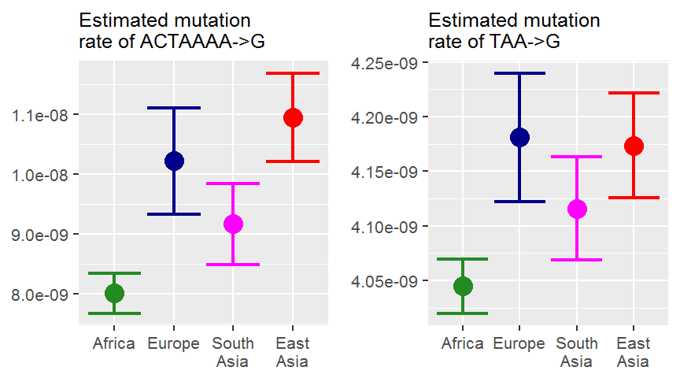

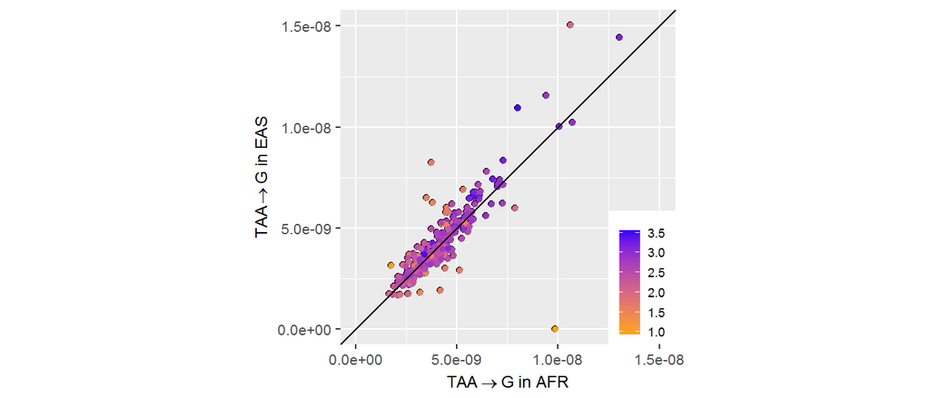

Based on the scatterplot above, it is possible that the profile of TAA->G is actually shaped by a small handful of 7mer outliers.

## Remaining TAT signals

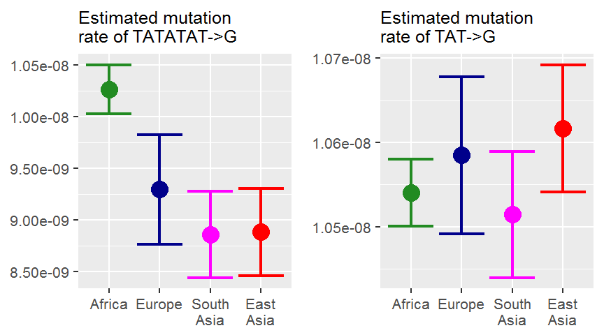

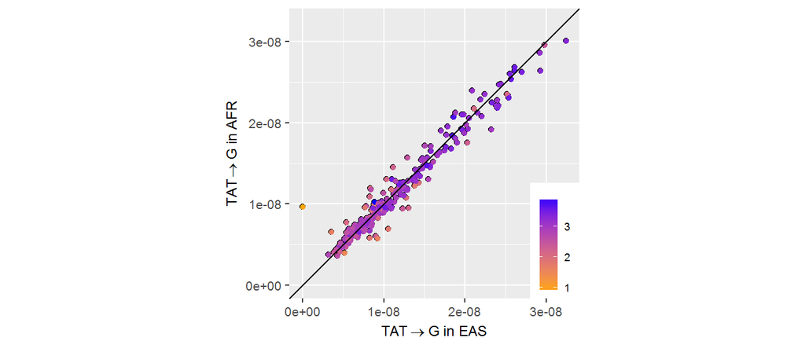

To be honest, I’m not really sure what the correct interpretation of this is.

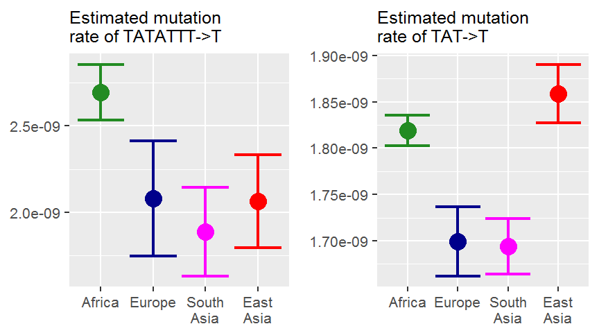

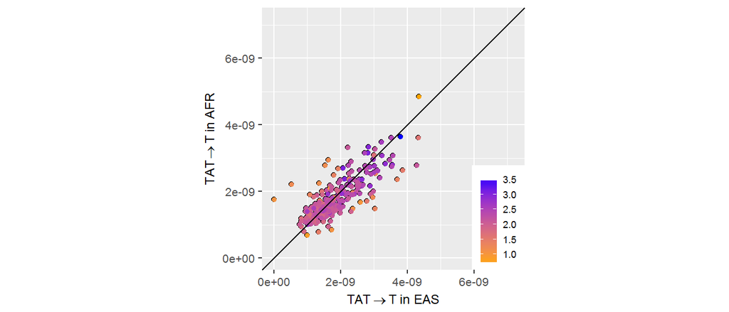